# Library

```r
library("forecast")
```

```r
library("graphics")
library("TTR")
library("TSA")
library(rio)
library(readxl)
library(dplyr)
library(ggplot2)
```

# Import Data

```r
data.1 <- read_excel("~/Downloads/Kel2_Data fix Proyek_VPdef.xls",
    sheet = "500", col_types = c("date",
        "numeric", "numeric", "numeric",
        "numeric", "numeric", "numeric",
        "numeric", "numeric", "numeric",
        "numeric", "numeric", "numeric",
        "numeric", "numeric", "numeric",
        "numeric", "numeric", "numeric",
        "numeric", "numeric"))
```

setelah data berhasi diimpor, kita pilih kolom dan baris yang akan digunakan

```r
data.1 <- data.1[201:300,c("date", "VPdef")]
```

# Eksplorasi Data

```r
str(data.1)
```

```
## tibble [100 × 2] (S3: tbl_df/tbl/data.frame)
##  $ date : POSIXct[1:100], format: "2020-02-01 09:30:00" "2020-02-01 09:40:00" ...
##  $ VPdef: num [1:100] 0.77 0.78 0.78 0.74 0.74 0.77 0.91 0.99 1.22 1.47 ...
```

```r
dim(data.1)
```

```
## [1] 100   2
```

```r
colSums(is.na(data.1))
```

```
##  date VPdef
##     0     0
```

```r
sum(duplicated(data.1))
```

```
## [1] 0
```

struktur data sudah sesuai dan tidak ditemukan adanya missing value ataupun data ganda. kemudian kita ubah agar terbaca sebagai data deret waktu

```r
data.1.ts <- ts(data.1$VPdef)
```

```r
summary(data.1.ts)
```

```
##    Min. 1st Qu.  Median    Mean 3rd Qu.    Max.
##   0.740   0.920   1.090   1.807   2.393   4.520
```

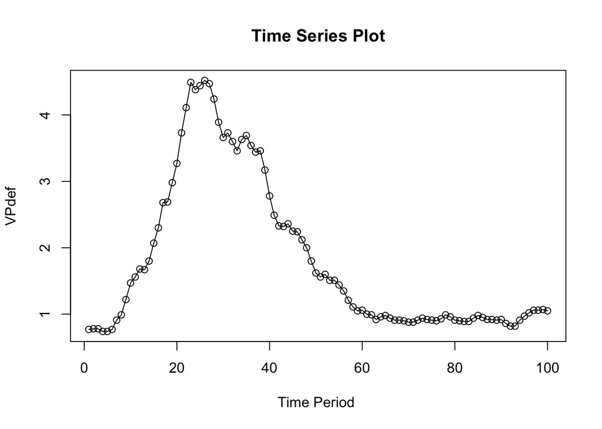

```r
ts.plot(data.1.ts, xlab="Time Period ", ylab="VPdef",
        main = "Time Series Plot")
points(data.1.ts)
```

berdasarkan plot yang terbentuk ada kenaikan tajam hingga periode ke-20, lalu menurun secara perlahan. pada periode ke-60 cenderung stabil. ini menunjukkan adanya fluktuasi jangka pendek dan tren jangka panjang. Perlu dilihat menggunakan data keseluruhan agar lebih mudah melihat pola yang terbentuk.

# Pembagian Data

data dibagi menjadi 80% data latih, dan 20% data uji

```r
train <- data.1[1:80,]
test <- data.1[81:100,]
train.ts <- ts(train$VPdef)
test.ts <- ts(test$VPdef)
```

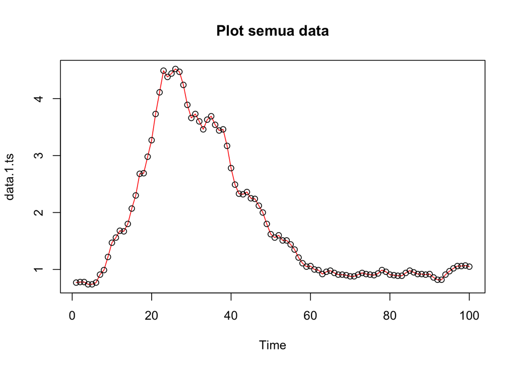

```r
plot(data.1.ts, col="red",main="Plot semua data")
points(data.1.ts)
```

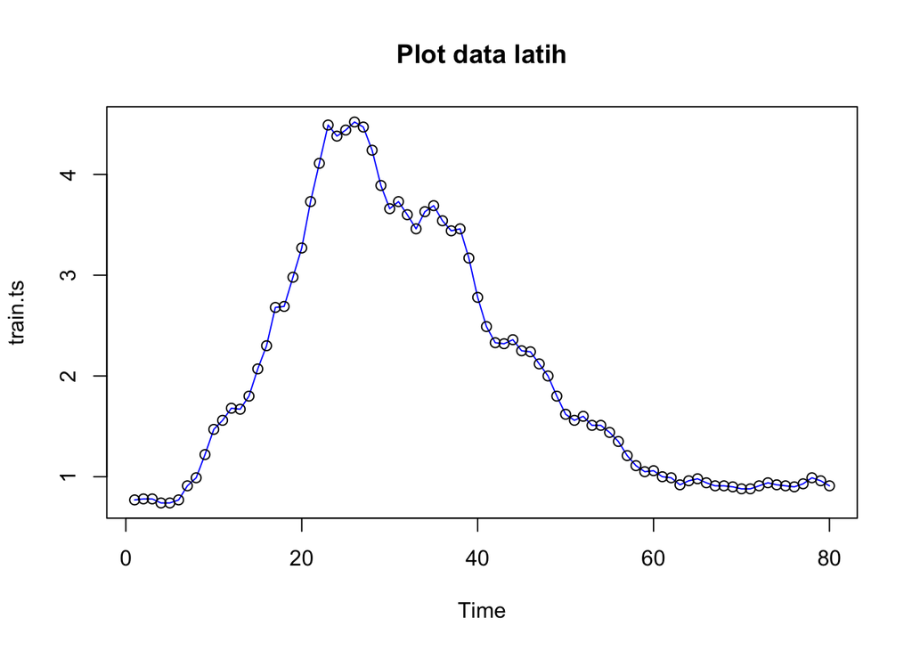

```r
#eksplorasi data latih
plot(train.ts, col="blue",main="Plot data latih")
points(train.ts)
```

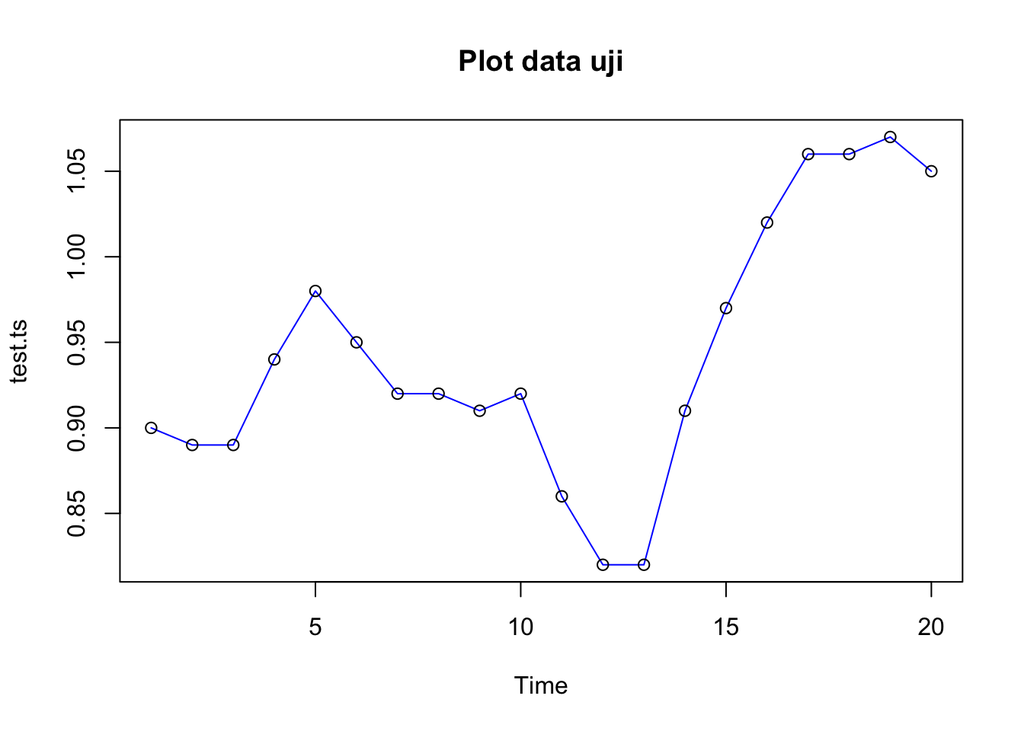

```r
plot(test.ts, col="blue",main="Plot data uji")
points(test.ts)
```

# SMA

pada kali ini saya menggunakan m=2 hasil dari mencoba-coba berbagai nilai m, yang berarti data pada periode tertentu kira-kira dipengaruhi oleh 2 periode data sebelumnya.

```r
data.sma<-SMA(train.ts, n=2)
data.sma
```

```
## Time Series:
## Start = 1
## End = 80
## Frequency = 1
##  [1]    NA 0.775 0.780 0.760 0.740 0.755 0.840 0.950 1.105 1.345 1.515 1.620
## [13] 1.675 1.735 1.935 2.185 2.490 2.685 2.835 3.125 3.500 3.920 4.300 4.435
## [25] 4.410 4.480 4.495 4.355 4.065 3.775 3.695 3.665 3.530 3.545 3.660 3.615
## [37] 3.490 3.450 3.315 2.975 2.635 2.410 2.325 2.340 2.305 2.245 2.180 2.060
## [49] 1.900 1.710 1.590 1.580 1.555 1.510 1.475 1.395 1.280 1.160 1.080 1.055
## [61] 1.030 0.995 0.955 0.940 0.970 0.960 0.925 0.910 0.905 0.890 0.880 0.895
## [73] 0.925 0.930 0.915 0.905 0.915 0.960 0.975 0.935
```

```r
data.ramal<-c(NA,data.sma)
data.ramal #forecast 1 periode ke depan
```

```
##  [1]    NA    NA 0.775 0.780 0.760 0.740 0.755 0.840 0.950 1.105 1.345 1.515
## [13] 1.620 1.675 1.735 1.935 2.185 2.490 2.685 2.835 3.125 3.500 3.920 4.300
## [25] 4.435 4.410 4.480 4.495 4.355 4.065 3.775 3.695 3.665 3.530 3.545 3.660
## [37] 3.615 3.490 3.450 3.315 2.975 2.635 2.410 2.325 2.340 2.305 2.245 2.180
## [49] 2.060 1.900 1.710 1.590 1.580 1.555 1.510 1.475 1.395 1.280 1.160 1.080
## [61] 1.055 1.030 0.995 0.955 0.940 0.970 0.960 0.925 0.910 0.905 0.890 0.880
## [73] 0.895 0.925 0.930 0.915 0.905 0.915 0.960 0.975 0.935
```

Selanjutnya akan dilakukan peramalan sejumlah data uji yaitu 20 periode. Pada metode SMA, hasil peramalan 20 periode ke depan akan bernilai sama dengan hasil peramalan 1 periode kedepan. Dalam hal ini akan dilakukan pengguabungan data aktual train, data hasil pemulusan dan data hasil ramalan 20 periode kedepan.

```r
data.gab<-cbind(aktual=c(train.ts,rep(NA,20)),pemulusan=c(data.sma,rep(NA,20)),ramalan=c(data.ramal,rep(data.ramal[length(data.ramal)],19)))
data.gab #forecast 20 periode ke depan
```

```
##        aktual pemulusan ramalan
##   [1,]   0.77        NA      NA
##   [2,]   0.78     0.775      NA
##   [3,]   0.78     0.780   0.775
##   [4,]   0.74     0.760   0.780
##   [5,]   0.74     0.740   0.760
##   [6,]   0.77     0.755   0.740
##   [7,]   0.91     0.840   0.755
##   [8,]   0.99     0.950   0.840
##   [9,]   1.22     1.105   0.950
##  [10,]   1.47     1.345   1.105
##  [11,]   1.56     1.515   1.345
##  [12,]   1.68     1.620   1.515
##  [13,]   1.67     1.675   1.620
##  [14,]   1.80     1.735   1.675
```

[output cut: 86 more lines]

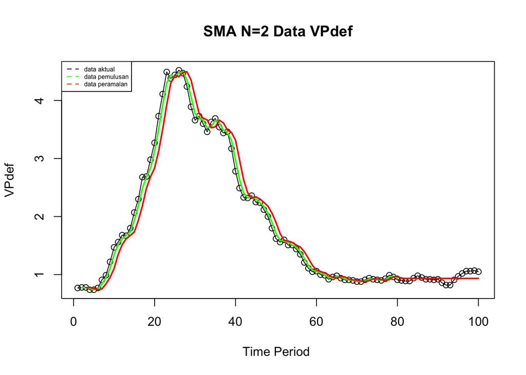

```r
ts.plot(data.1.ts, xlab="Time Period ", ylab="VPdef", main= "SMA N=2 Data VPdef")
points(data.1.ts)
lines(data.gab[,2],col="green",lwd=2)
lines(data.gab[,3],col="red",lwd=2)
legend("topleft",c("data aktual","data pemulusan","data peramalan"), lty=8, col=c("black","green","red"), cex=0.5)
```

```r
#Menghitung nilai keakuratan data latih
error_train.sma = train.ts-data.ramal[1:length(train.ts)]
SSE_train.sma = sum(error_train.sma[3:length(train.ts)]^2)
MSE_train.sma = mean(error_train.sma[3:length(train.ts)]^2)
MAPE_train.sma = mean(abs((error_train.sma[3:length(train.ts)]/train.ts[3:length(train.ts)])*100))

akurasi_train.sma <- matrix(c(SSE_train.sma, MSE_train.sma, MAPE_train.sma))
row.names(akurasi_train.sma)<- c("SSE", "MSE", "MAPE")
colnames(akurasi_train.sma) <- c("Akurasi m = 2")
akurasi_train.sma
```

```
##      Akurasi m = 2
## SSE     3.87542500
## MSE     0.04968494
## MAPE    7.33042317
```

Dalam hal ini nilai MAPE data latih pada metode pemulusan SMA adalah 7.33%, nilai ini dapat dikategorikan sebagai nilai akurasi yang sangat baik. Selanjutnya dilakukan perhitungan nilai MAPE data uji pada metde pemulusan SMA.

```r
#Menghitung nilai keakuratan data uji
error_test.sma = test.ts-data.gab[81:100,3]
SSE_test.sma = sum(error_test.sma^2)
MSE_test.sma = mean(error_test.sma^2)
MAPE_test.sma = mean(abs((error_test.sma/test.ts*100)))

akurasi_test.sma <- matrix(c(SSE_test.sma, MSE_test.sma, MAPE_test.sma))
row.names(akurasi_test.sma)<- c("SSE", "MSE", "MAPE")
colnames(akurasi_test.sma) <- c("Akurasi m = 2")
akurasi_test.sma
```

```
##      Akurasi m = 2
## SSE       0.112700
## MSE       0.005635
## MAPE      6.347758
```

Perhitungan akurasi menggunakan data latih menghasilkan nilai MAPE yang kurang dari 10% sehingga nilai akurasi ini dapat dikategorikan sebagai sangat baik.

# DMA

Selanjutnya akan kita coba pemulusan menggunakan metode DMA

```r
dma <- SMA(data.sma, n = 4)
At <- 2*data.sma - dma
Bt <- 2/(4-1)*(data.sma - dma)
data.dma<- At+Bt
data.ramal2<- c(NA, data.dma)

t = 1:20
f = c()

for (i in t) {
  f[i] = At[length(At)] + Bt[length(Bt)]*(i)
}

data.gab2 <- cbind(aktual = c(train.ts,rep(NA,20)), pemulusan1 = c(data.sma,rep(NA,20)),pemulusan2 = c(data.dma, rep(NA,20)),At = c(At, rep(NA,20)), Bt = c(Bt,rep(NA,20)),ramalan = c(data.ramal2, f[-1]))
data.gab2
```

```
##        aktual pemulusan1 pemulusan2      At            Bt   ramalan
##   [1,]   0.77         NA         NA      NA            NA        NA
##   [2,]   0.78      0.775         NA      NA            NA        NA
##   [3,]   0.78      0.780         NA      NA            NA        NA
##   [4,]   0.74      0.760         NA      NA            NA        NA
##   [5,]   0.74      0.740  0.7004167 0.71625 -0.0158333333        NA
##   [6,]   0.77      0.755  0.7487500 0.75125 -0.0025000000 0.7004167
##   [7,]   0.91      0.840  0.9504167 0.90625  0.0441666667 0.7487500
##   [8,]   0.99      0.950  1.1645833 1.07875  0.0858333333 0.9504167
##   [9,]   1.22      1.105  1.4258333 1.29750  0.1283333333 1.1645833
##  [10,]   1.47      1.345  1.8200000 1.63000  0.1900000000 1.4258333
##  [11,]   1.56      1.515  1.9920833 1.80125  0.1908333333 1.8200000
##  [12,]   1.68      1.620  1.9929167 1.84375  0.1491666667 1.9920833
##  [13,]   1.67      1.675  1.9020833 1.81125  0.0908333333 1.9929167
##  [14,]   1.80      1.735  1.8995833 1.83375  0.0658333333 1.9020833
```

[output cut: 86 more lines]

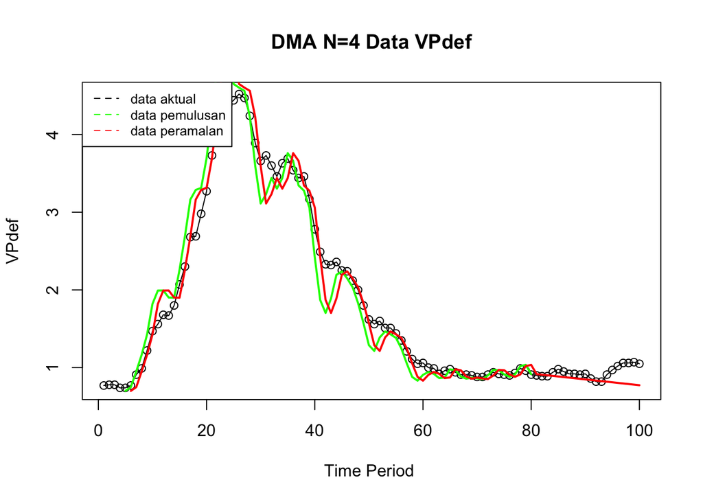

```r
ts.plot(data.1.ts, xlab="Time Period ", ylab="VPdef", main= "DMA N=4 Data VPdef")
points(data.1.ts)
lines(data.gab2[,3],col="green",lwd=2)
lines(data.gab2[,6],col="red",lwd=2)
legend("topleft",c("data aktual","data pemulusan","data peramalan"), lty=8, col=c("black","green","red"), cex=0.8)
```

```r
#Menghitung nilai keakuratan data latih
error_train.dma = train.ts-data.ramal2[1:length(train.ts)]
SSE_train.dma = sum(error_train.dma[8:length(train.ts)]^2)
MSE_train.dma = mean(error_train.dma[8:length(train.ts)]^2)
MAPE_train.dma = mean(abs((error_train.dma[8:length(train.ts)]/train.ts[8:length(train.ts)])*100))

akurasi_train.dma <- matrix(c(SSE_train.dma, MSE_train.dma, MAPE_train.dma))
row.names(akurasi_train.dma)<- c("SSE", "MSE", "MAPE")
colnames(akurasi_train.dma) <- c("Akurasi m = 4")
akurasi_train.dma
```

```
##      Akurasi m = 4
## SSE     4.42459392
## MSE     0.06061088
## MAPE    7.52725780
```

Perhitungan akurasi pada data latih menggunakan nilai MAPE menghasilkan nilai MAPE yang kurang dari 10% sehingga dikategorikan sangat baik. Selanjutnya, perhitungan nilai akurasi dilakukan pada data uji.

```r
#Menghitung nilai keakuratan data uji
error_test.dma = test.ts-data.gab2[81:100,6]
SSE_test.dma = sum(error_test.dma^2)
MSE_test.dma = mean(error_test.dma^2)
MAPE_test.dma = mean(abs((error_test.dma/test.ts*100)))

akurasi_test.dma <- matrix(c(SSE_test.dma, MSE_test.dma, MAPE_test.dma))
row.names(akurasi_test.dma)<- c("SSE", "MSE", "MAPE")
colnames(akurasi_test.dma) <- c("Akurasi m = 4")
akurasi_test.dma
```

```
##      Akurasi m = 4
## SSE     0.41395625
## MSE     0.02069781
## MAPE   10.41039880
```

# SES

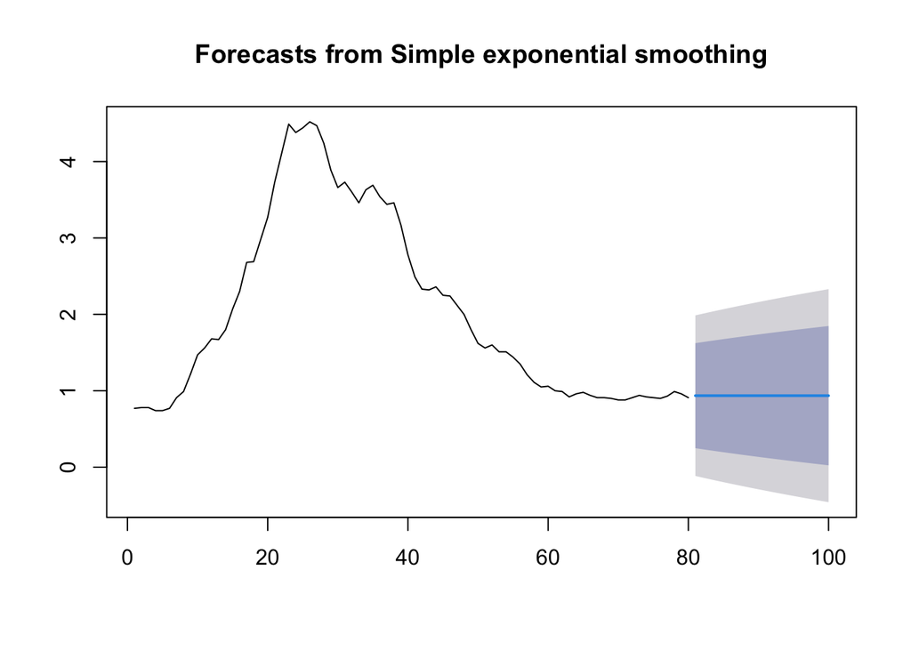

```r
ses.1 <- ses(train.ts, h = 20, alpha = 0.2)
plot(ses.1)
```

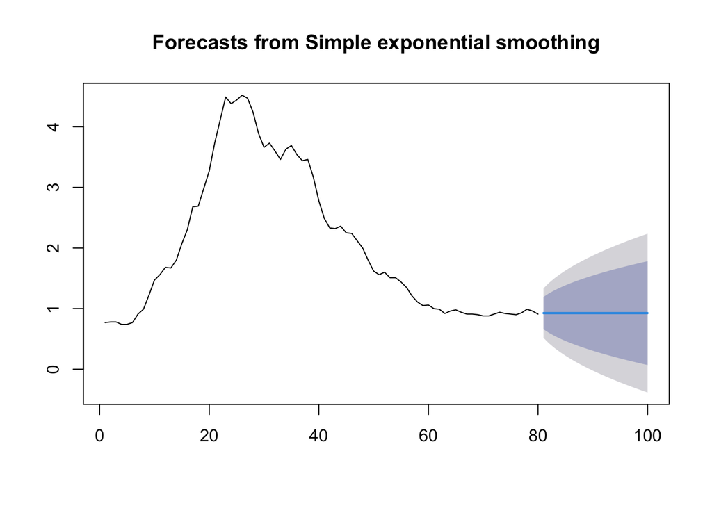

```r
ses.2<- ses(train.ts, h = 20, alpha = 0.7)
plot(ses.2)
```

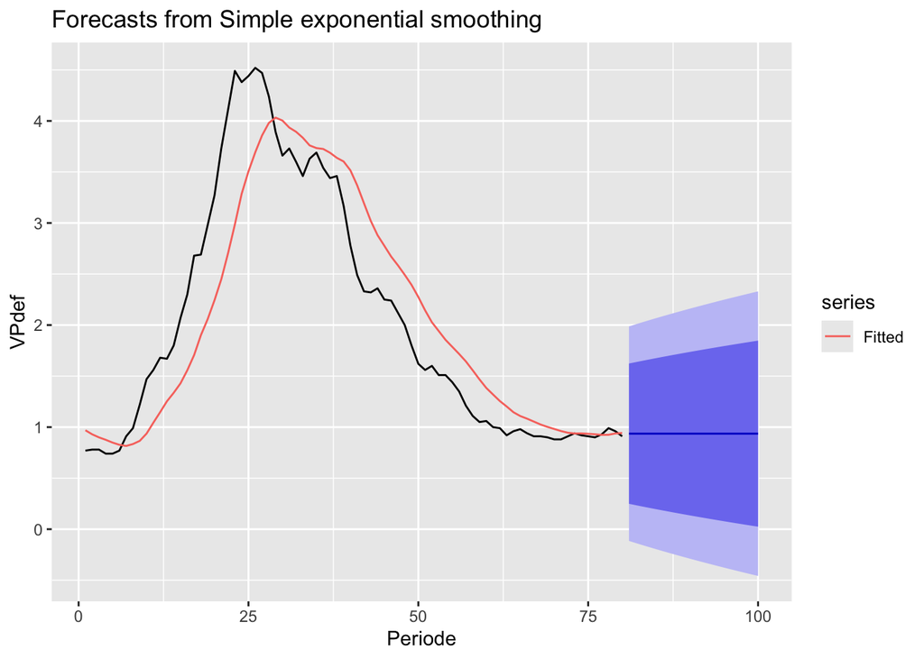

```r
autoplot(ses.1) +
  autolayer(fitted(ses.1), series="Fitted") +
  ylab("VPdef") + xlab("Periode")
```

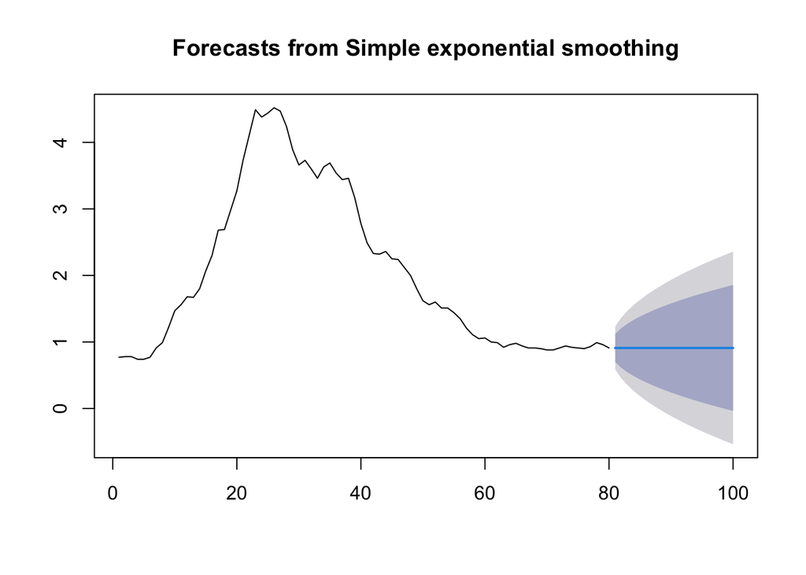

```r
ses.opt <- ses(train.ts, h = 20, alpha = NULL)
plot(ses.opt)
```

```r
accuracy(ses.1,test$VPdef)
```

```
##                        ME       RMSE        MAE        MPE      MAPE     MASE
## Training set -0.002082449 0.52937652 0.40654059 -5.2546238 20.110297 3.600528
## Test set      0.007021523 0.07496867 0.06059785  0.1276739  6.364866 0.536685
##                   ACF1
## Training set 0.9673973
## Test set            NA
```

```r
accuracy(ses.2,test$VPdef)
```

```
##                       ME       RMSE        MAE        MPE     MAPE      MASE
## Training set 0.002742581 0.20541773 0.14187734 -0.1975969 6.716885 1.2565369
## Test set     0.017129552 0.07657951 0.05958704  1.2062376 6.188135 0.5277328
##                   ACF1
## Training set 0.8158818
## Test set            NA
```

```r
accuracy(ses.opt,test$VPdef)
```

```
##                       ME      RMSE       MAE       MPE     MAPE      MASE
## Training set 0.005685249 0.1630165 0.1154418 0.4761527 5.793195 1.0224104
## Test set     0.032994999 0.0816068 0.0609990 2.8991387 6.236663 0.5402378
##                   ACF1
## Training set 0.6335455
## Test set            NA
```

Pada metode SES menunjukkan MAPE yang lebih baik lagii dibanding metode SMA

# Kesimpulan